# EDA Assessment 1 American Bankruptcy

2025-10-16

## R Markdown

Basic EDA for American Bankruptcy Dataset

```r
pkgs <- c("tidyverse","ggplot2","corrplot","dplyr","RColorBrewer", "data.table", "rlang", "patchwork")

for(p in pkgs){
    if (!require(p,character.only=TRUE)) install.packages(p)
}
```

We conduct EDA on the preprocessed dataset located in the Data folder on Github.

```r
# Downloads the dataset even if the file is not present on device

url <- "https://raw.githubusercontent.com/railtonjamesl-collab/DataScienceFanClub/main/Data/preprocessed_data.csv"

if (!file.exists("preprocessed_data.csv")) {
  message("Downloading large dataset, this may take a few minutes.")
  download.file(url, "preprocessed_data.csv", mode = "wb")
}

dataset <- fread("preprocessed_data.csv")
```

```r
cat("\nPercentage of years that are labeled failed:", (length(dataset$company_name[dataset$status_label_1yr=="failed"]) / length(dataset$company_name))*100,"%\n")
```

```
##
## Percentage of years that are labeled failed: 1.006548 %
```

```r
cat("\nPercentage of companies that end up bankrupt:", (length(dataset$company_name[dataset$status_label_1yr=="failed"]) / length(unique(dataset$company_name)))*100,"%\n")
```

```
##
## Percentage of companies that end up bankrupt: 8.362899 %
```

Clearly we have a large imbalance in alive to failed companies. This will have a large impact on certain models that will be used within this report, meaning we must introduce methods such as SMOTE and weightings to rectify this issue. For a visual representation, we provide a pie chart:

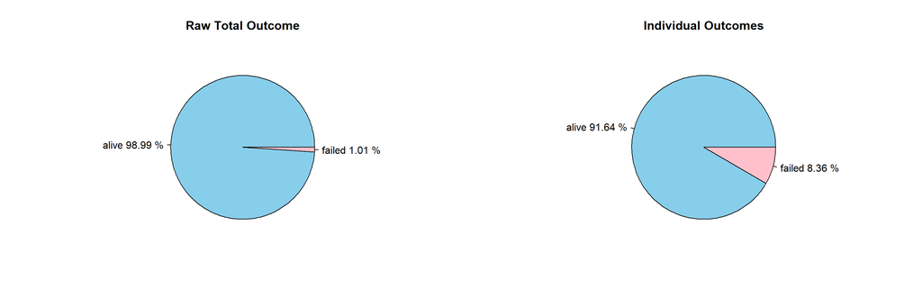

```r
# Raw Total Status Labels
info1 <- c(sum(dataset$status_label_1yr == "alive"), sum(dataset$status_label_1yr == "failed"))
perc1 <- round(info1 / sum(info1) * 100, 2)
names1 <- paste(c("alive", "failed"), perc1, "%")

# Individual Outcomes
info2 <- c(length(unique(dataset$company_name)) - length(dataset$company_name[dataset$status_label_1yr=="failed"]), length(dataset$company_name[dataset$status_label_1yr=="failed"]))
perc2 <- round(info2 / sum(info2) * 100, 2)
names2 <- paste(c("alive", "failed"), perc2, "%")

par(mfrow = c(1, 2))

pie(info1, labels = names1, col = c("skyblue", "pink"), main = "Raw Total Outcome")
pie(info2, labels = names2, col = c("skyblue", "pink"), main = "Individual Outcomes")
```

If we run a basic summary of a variable we see a major issue of outliers.

```r
summary(dataset$X1)
```

```
##      Min.   1st Qu.    Median      Mean   3rd Qu.      Max.
##     -7.76     28.20    150.44   1091.25    614.85 131339.00
```

```r
summary(dataset$X2)
```

```
##     Min.  1st Qu.   Median     Mean  3rd Qu.     Max.
##     -0.7     27.0    172.7   2040.6    909.0 374623.0
```

The large difference between mean and median is primarily from the existence of major companies that have much higher values in variables skewing the mean. We can plot this on a boxplot for a visual representation.

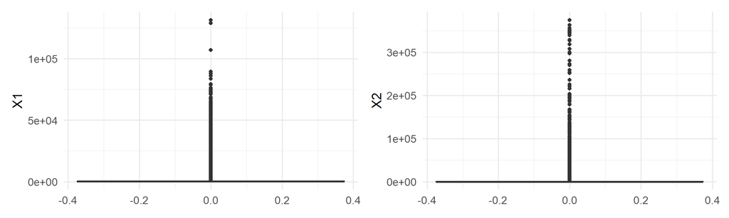

```r
box_x1 <- ggplot(dataset, aes(y = X1)) + geom_boxplot() + theme_minimal(base_size = 13)
box_x2 <- ggplot(dataset, aes(y = X2)) + geom_boxplot() + theme_minimal(base_size = 13)

box_x1 + box_x2
```

We see that the majority of values lay around 0, yet the outliers completely skew the data making it difficult to gather meaningful information from these graphs alone. These properties are not just present in X1 and X2, but all variables of interest.

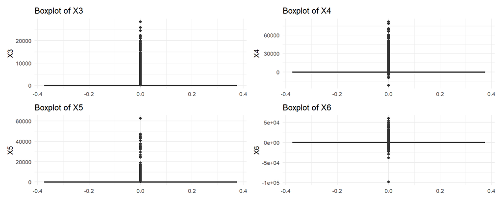

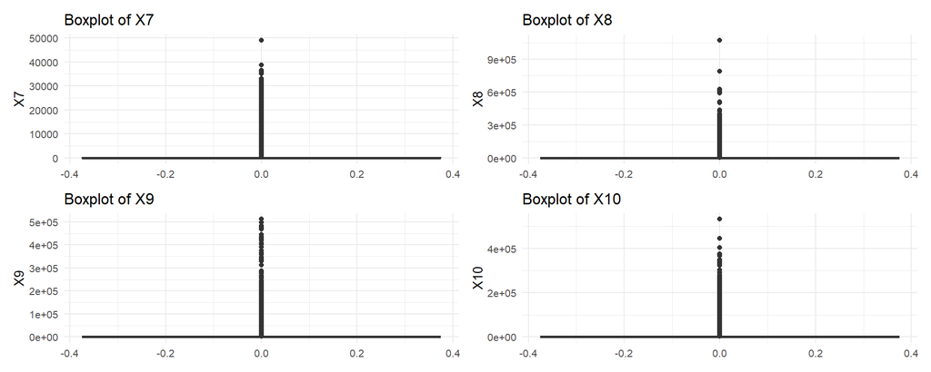

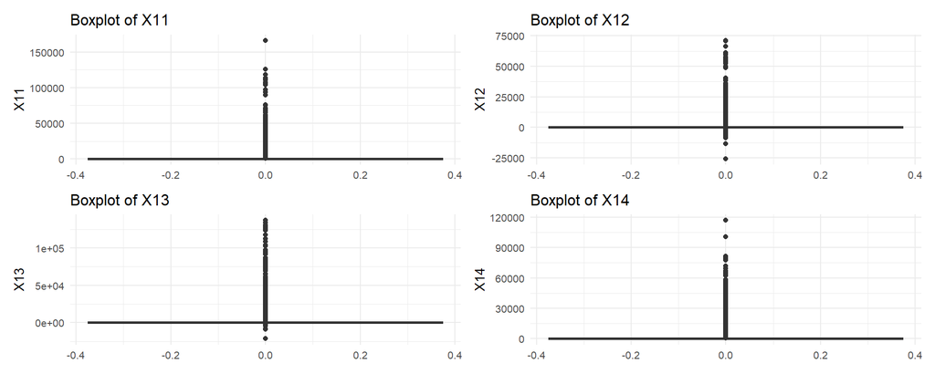

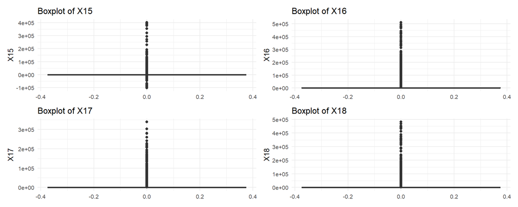

```r
df_covariates <- dataset[, -c(1:6, 25:78)]
df_covariates_multplot <- df_covariates[, -c(1,2)] # For this analysis, we are only interested in base features; no lag features
covariates <- names(df_covariates_multplot)
boxplots <- list()
for (i in covariates) {
  p <-ggplot(dataset, aes(y = .data[[i]])) + geom_boxplot() + labs(title = paste("Boxplot of", i), y = i) + theme_minimal(base_size = 10)

  boxplots[[i]] <- p
}

boxplot_groups <- split(boxplots, ceiling(seq_along(boxplots) / 4))

for (i in seq_along(boxplot_groups)) {
  print(wrap_plots(boxplot_groups[[i]], ncol = 2))
}
```

In all variables of interest, we see the same issue arising. However, without expert knowledge it is not hard to justify the removal of these variables. Hence, we will introduce a transformation as an attempt to standardise these variables. This will greatly help us with certain models which will be impacted by these outliers, reducing difficulties. The transformation in question has been justly explored in the Data section of the report, yet we will briefly explain what lead us to choose that particular transformation.

We now plot how many companies are present each year.

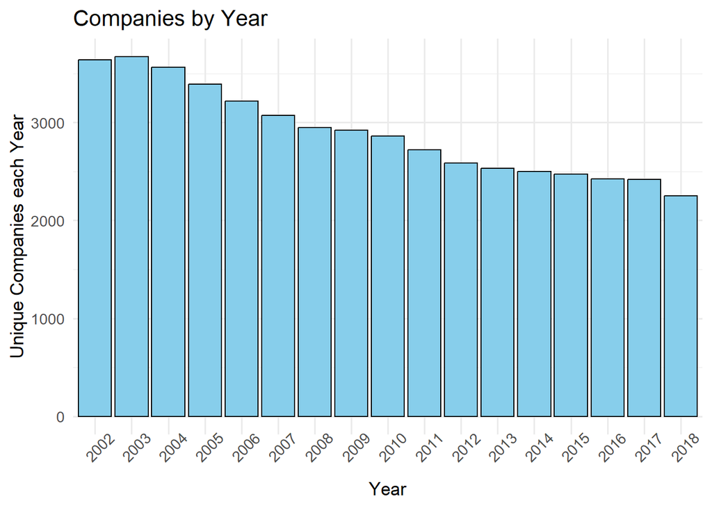

```r
companies_by_year <- dataset %>% group_by(year) %>% summarise(num_companies = n_distinct(company_name))
barplot1 <- ggplot(companies_by_year, aes(x = factor(year), y = num_companies)) +
            geom_col(color = "black", fill = "skyblue") +
            labs(title = "Companies by Year", x = "Year", y = "Unique Companies each Year") +
            theme_minimal(base_size = 13) +
            theme(axis.text.x = element_text(angle = 45))

barplot1
```

We see a steady decrease in the number of companies active each year. We can see the difference in companies over each year in more depth by seeing the number of companies which leave the dataset, regardless of if they went bankrupt or not.

```r
new_comp = list()
left_comp = list()
alive_list = list()
failed_list = list()
prev_total = 0
for (i in unique(dataset$year)) {
  alive_year <- length(dataset$company_name[dataset$status_label_1yr=="alive" & dataset$year==i])
  failed_year <- length(dataset$company_name[dataset$status_label_1yr=="failed" & dataset$year==i])
  current_year_companies <- unique(dataset$company_name[dataset$year == i])
  next_year_companies <- unique(dataset$company_name[dataset$year == i + 1])
  new_companies <- setdiff(next_year_companies, current_year_companies)
  left_companies <- setdiff(current_year_companies, next_year_companies)
  key_next <- as.character(i + 1)
  new_comp[[key_next]] <- new_companies
  left_comp[[key_next]] <- left_companies
  alive_list[[key_next]] <- alive_year
  failed_list[[key_next]] <- failed_year

  total_this_year <- alive_year + failed_year

  cat(
    paste0("\nYear: ", i),
    "\n  Total number of companies recorded this year: ", total_this_year,
    "\n  Did not go bankrupt this year: ", alive_year,
    "\n  Went bankrupt within this year: ", failed_year,
    "\n  New entrants next year (", i + 1, "): ", length(new_comp[[key_next]]),
    "\n  Absent companies next year (", i + 1, "): ", length(left_comp[[key_next]]),"\n",
    sep = ""
  )

  prev_total <- total_this_year
}
```

```
##
## Year: 2002
##   Total number of companies recorded this year: 3639
##   Did not go bankrupt this year: 3625
##   Went bankrupt within this year: 14
##   New entrants next year (2003): 316
##   Absent companies next year (2003): 284
##
## Year: 2003
##   Total number of companies recorded this year: 3671
##   Did not go bankrupt this year: 3646
##   Went bankrupt within this year: 25
##   New entrants next year (2004): 128
##   Absent companies next year (2004): 234
##
## Year: 2004
##   Total number of companies recorded this year: 3565
##   Did not go bankrupt this year: 3525
##   Went bankrupt within this year: 40
##   New entrants next year (2005): 96
##   Absent companies next year (2005): 271
##
## Year: 2005
##   Total number of companies recorded this year: 3390
##   Did not go bankrupt this year: 3353
##   Went bankrupt within this year: 37
##   New entrants next year (2006): 89
##   Absent companies next year (2006): 262
##
## Year: 2006
##   Total number of companies recorded this year: 3217
##   Did not go bankrupt this year: 3172
##   Went bankrupt within this year: 45
##   New entrants next year (2007): 129
##   Absent companies next year (2007): 277
##
## Year: 2007
##   Total number of companies recorded this year: 3069
##   Did not go bankrupt this year: 3018
##   Went bankrupt within this year: 51
```

[output cut: 64 more lines]

```
##   Absent companies next year (2017): 180
##
## Year: 2017
##   Total number of companies recorded this year: 2416
##   Did not go bankrupt this year: 2397
##   Went bankrupt within this year: 19
##   New entrants next year (2018): 113
##   Absent companies next year (2018): 281
##
## Year: 2018
##   Total number of companies recorded this year: 2248
##   Did not go bankrupt this year: 2220
##   Went bankrupt within this year: 28
##   New entrants next year (2019): 0
##   Absent companies next year (2019): 2248
```

See that the total number of companies recorded in one year is simply the companies that did not bankrupt from the previous year plus the new entrants minus the companies who left the study within the year (taking into account the number of companies who left because of bankruptcy). Clearly in the vast majority of years there are more companies leaving the study then there are joining it. With expert knowledge it will be possible to evaluate why this is the case. We can further this analysis by plotting failed companies and companies that left the study to visualise and spot any possible trends.

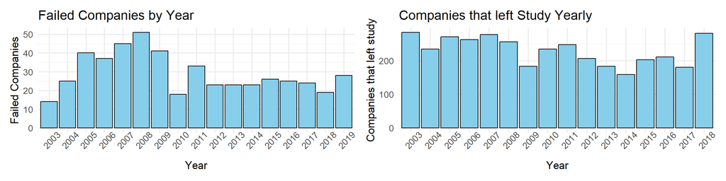

```r
failed_df <- data.frame(year = as.integer(names(failed_list)), failed = as.numeric(failed_list))
barplot_f <- ggplot(failed_df, aes(x = factor(year), y = failed)) +
            geom_col(color = "black", fill = "skyblue") +
            labs(title = "Failed Companies by Year", x = "Year", y = "Failed Companies") +
            theme_minimal(base_size = 13) +
            theme(axis.text.x = element_text(angle = 45))

num_left_comp <- sapply(left_comp, length)
num_left_comp <- num_left_comp[names(num_left_comp) != "2019"] # skews data heavily, useless for us
left_df <- data.frame(year = as.integer(names(num_left_comp)), left = as.numeric(num_left_comp))
barplot_left <- ggplot(left_df, aes(x = factor(year), y = left)) +
            geom_col(color = "black", fill = "skyblue") +
            labs(title = "Companies that left Study Yearly", x = "Year", y = "Companies that left study") +
            theme_minimal(base_size = 13) +
            theme(axis.text.x = element_text(angle = 45))

barplot_f + barplot_left
```

There seemed to be a large amount of failed companies around the mid to late 2000s. This could be in part to the Financial Crisis of 2008, which heavily impacted many business worldwide but in particular those located in the United States. Yet, without expert knowledge it is only a suggestion and there may be external factors that heavily impacted the bankruptcy rate. Furthermore, with a time scale of just over 15 years it is hard to gauge how regular, or irregular, our data is with respect to the past.

We can extend this to other variables. In each scenario we will take the mean of said variable and visualise the changes over each year in the dataset to see how values fluctuate in that time frame. We start with X1 and X2.

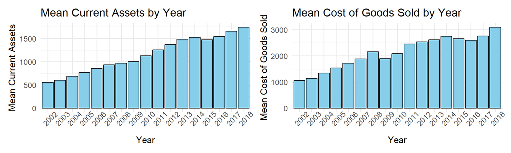

```r
mean_curr_assets <- dataset[, .(mean_curr_assets = mean(X1)), by = year][order(year)]

barplot2 <- ggplot(mean_curr_assets, aes(x = factor(year), y = mean_curr_assets)) +
            geom_col(color = "black", fill = "skyblue") +
            labs(title = "Mean Current Assets by Year", x = "Year", y = "Mean Current Assets") +
            theme_minimal(base_size = 13) +
            theme(axis.text.x = element_text(angle = 45))

mean_cost_goods_sold <- dataset[, .(mean_cost_goods_sold = mean(X2)), by = year][order(year)]

barplot3 <- ggplot(mean_cost_goods_sold, aes(x = factor(year), y = mean_cost_goods_sold)) +
            geom_col(color = "black", fill = "skyblue") +
            labs(title = "Mean Cost of Goods Sold by Year", x = "Year", y = "Mean Cost of Goods Sold") +
            theme_minimal(base_size = 13) +
            theme(axis.text.x = element_text(angle = 45))

barplot2 + barplot3
```

Both variables follow similar patterns, that is an increase in the mean variable as time increases. This may be because of inflation, or as we are using the mean then many major firms have simply grown much faster than others raising the mean slightly; withouth expert knowledge it is hard to tell.

Like before, it is important to see whether all variables provide similar results. Hence we extend to all remaining variables of interest.

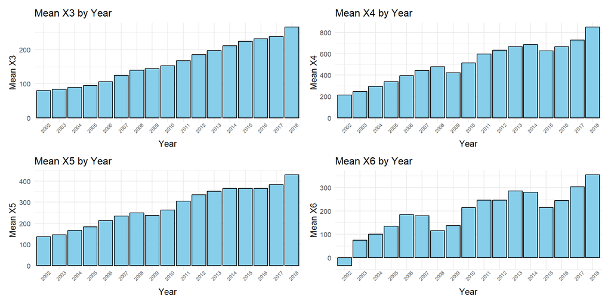

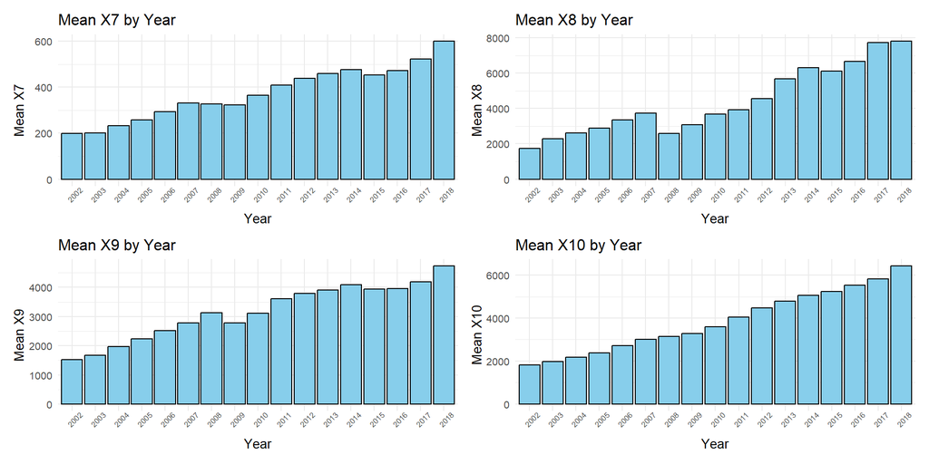

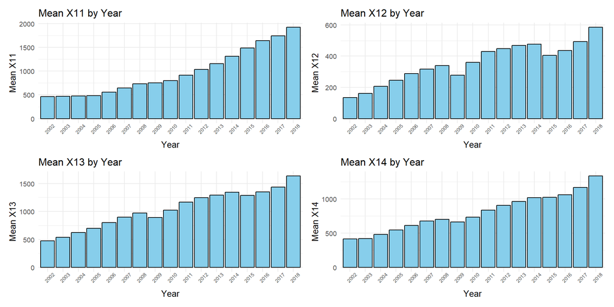

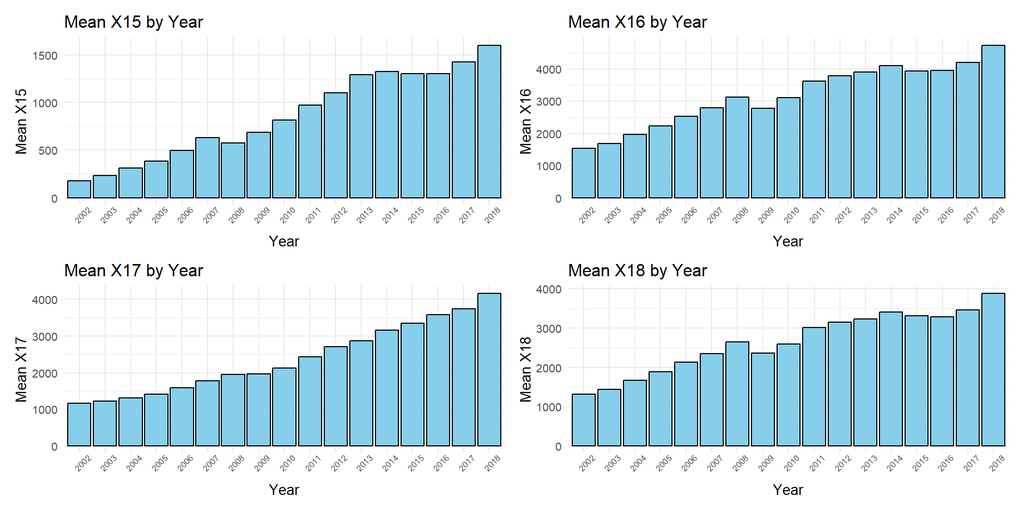

```r
plots <- list()
for (var in covariates) {
  mean_data <- dataset[, .(mean_value = mean(get(var))), by = year][order(year)]
  p <- ggplot(mean_data, aes(x = factor(year), y = mean_value)) +
       geom_col(color = "black", fill = "skyblue") +
       labs(title = paste("Mean", var, "by Year"), x = "Year", y = paste("Mean", var)) +
       theme_minimal(base_size = 10) +
       theme(axis.text.x = element_text(angle = 45, size = 6))

  plots[[var]] <- p
}

plot_groups <- split(plots, ceiling(seq_along(plots) / 4))

for (i in seq_along(plot_groups)) {
  print(wrap_plots(plot_groups[[i]], ncol = 2))
}
```

We can see that in all plots there seems to be a steady increase in mean value over time, with some slight variation particularly around the 2007/8 frame perhaps related to the ongoing financial crisis.

We will now shit our attention to histograms where it becomes readily apparent about the importance effect that outliers have on our data.

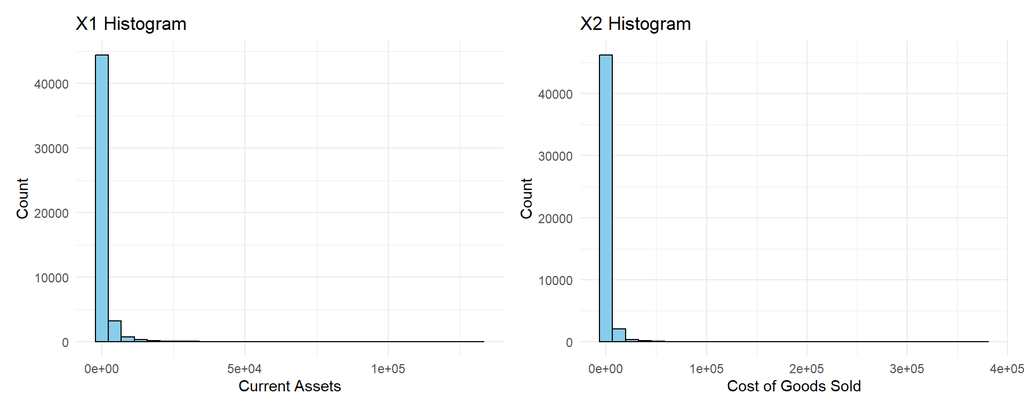

```r
histbase_1 <- ggplot(data = dataset, aes(x = dataset$X1)) +
              labs(title = paste("X1 Histogram"), x = "Current Assets", y = "Count") +
              geom_histogram(bins=30, color = "black", fill = "skyblue") +
              theme_minimal()

histbase_2 <- ggplot(data = dataset, aes(x = dataset$X2)) +
              labs(title = paste("X2 Histogram"), x = "Cost of Goods Sold", y = "Count") +
              geom_histogram(bins=30, color = "black", fill = "skyblue") +
              theme_minimal()

histbase_1 + histbase_2
```

This is similar to what we witnessed on the boxplot for these variables. Therefore to rectify this large discrepancy in values, we can perform a transformation. For more detail please read the Data Scaling file.

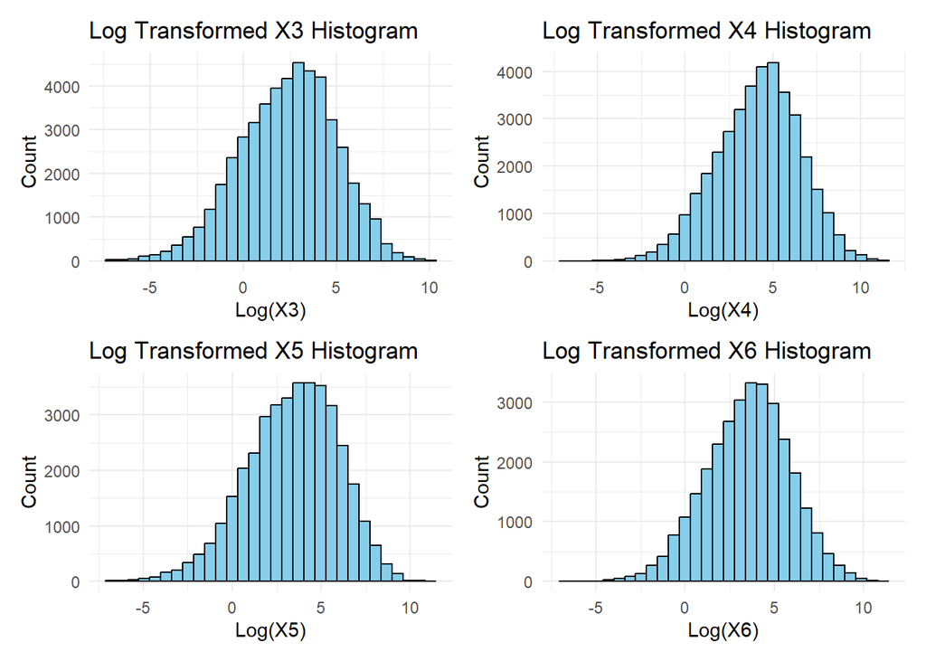

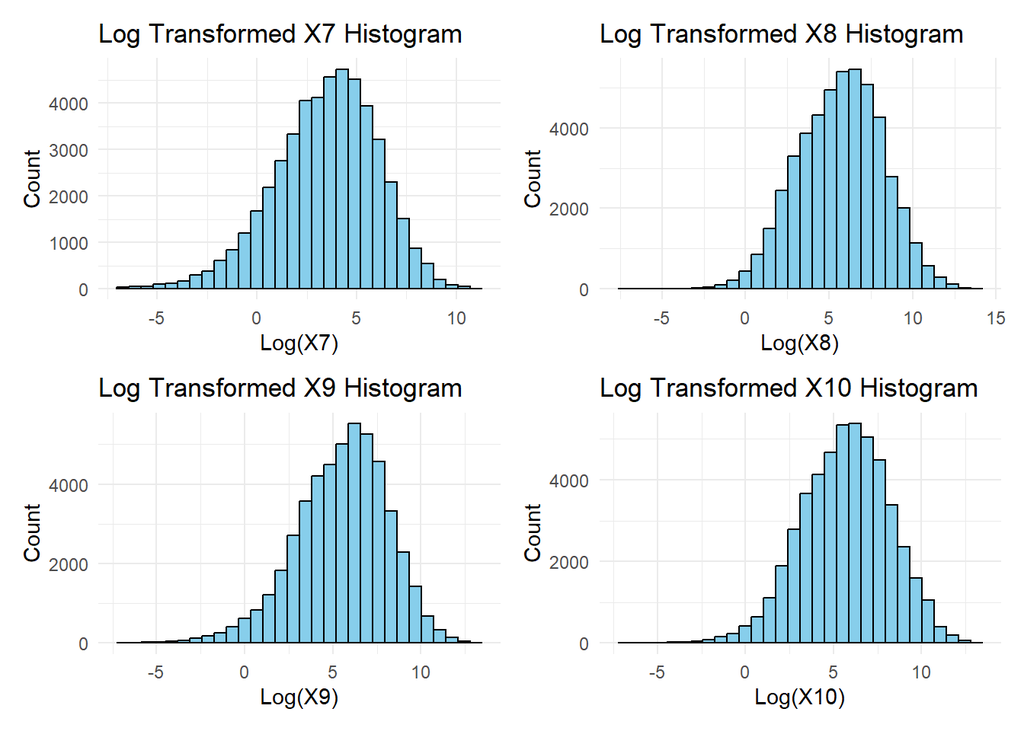

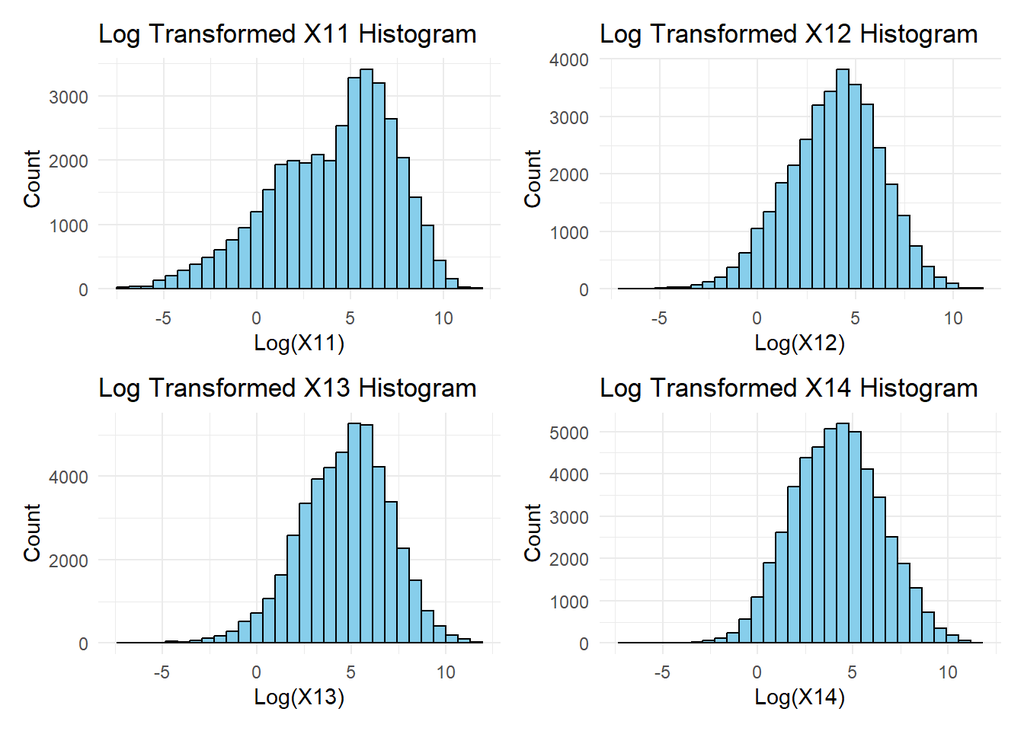

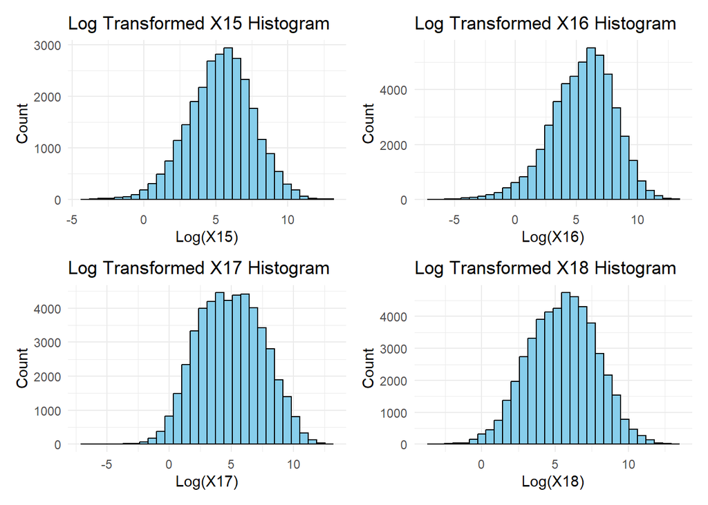

```r
histplots <- list()
for (var in covariates) {
  p <- ggplot(data = dataset, aes(x = log(.data[[var]]))) +
     labs(title = paste("Log Transformed", var, "Histogram"), x = paste0("Log(",var,")"), y = "Count") +
     geom_histogram(bins=30, color = "black", fill = "skyblue") +
     theme_minimal()

  histplots[[var]] <- p
}

histplot_groups <- split(histplots, ceiling(seq_along(histplots) / 4))

for (i in seq_along(histplot_groups)) {
  print(wrap_plots(histplot_groups[[i]], ncol = 2))
}
```

Without further inspection our plots look to follow a normal distribution, hence succeeding in standardising the variables. Yet, a variable such as X15 has over 22000 observations simply ignored due to the high frequency of negative values associated with said variable. Therefore it is illogical to proceed with such a transformation as we are essentially ignoring data. This leads us to a more apt transformation called Log-Modulus.

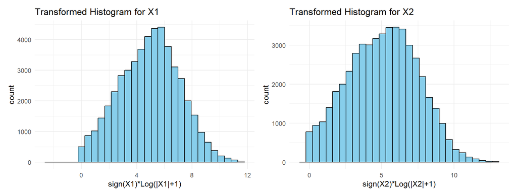

```r
# We provide a log transform on the absolute value of the variable (and add 1) then multiply by the original sign of the variable

histp1 <- ggplot(data = dataset, aes(x = log1p(abs(X1))*sign(X1))) +
          labs(title = "Transformed Histogram for X1", x = "sign(X1)*Log(|X1|+1)", y = "count") +
          geom_histogram(bins=30, color = "black", fill = "skyblue") + theme_minimal()

histp2 <- ggplot(data = dataset, aes(x = log1p(abs(X2))*sign(X2))) +
          labs(title = "Transformed Histogram for X2", x = "sign(X2)*Log(|X2|+1)", y = "count") +
          geom_histogram(bins=30, color = "black", fill = "skyblue") + theme_minimal()

histp1 + histp2
```

We extend this to the remaining variables for clarity.

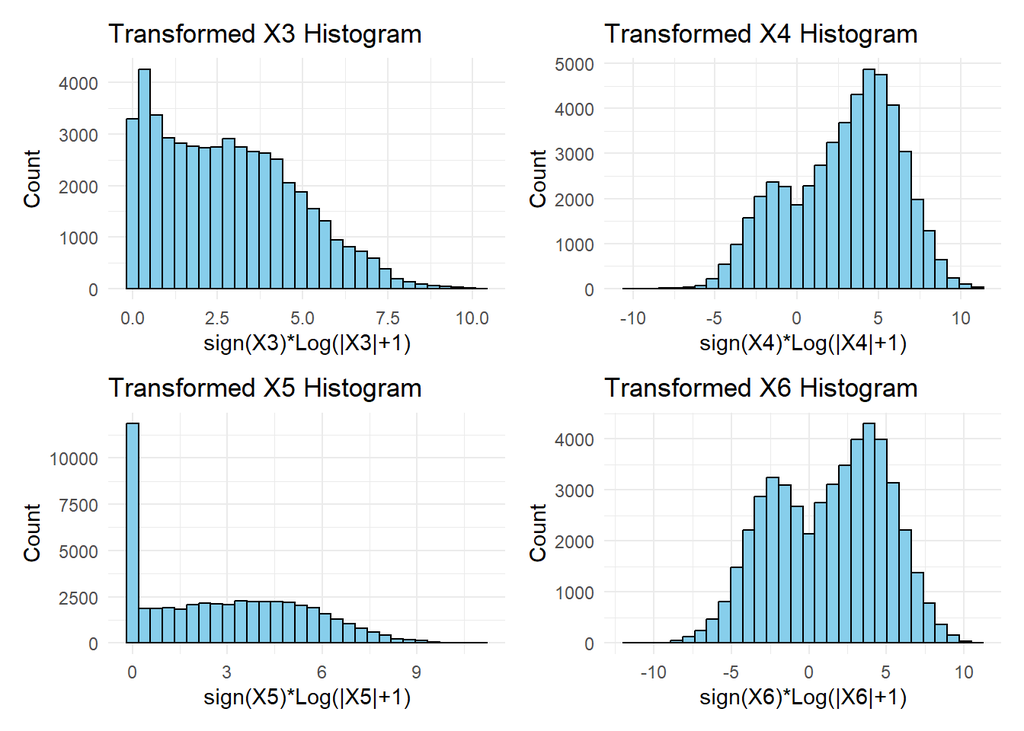

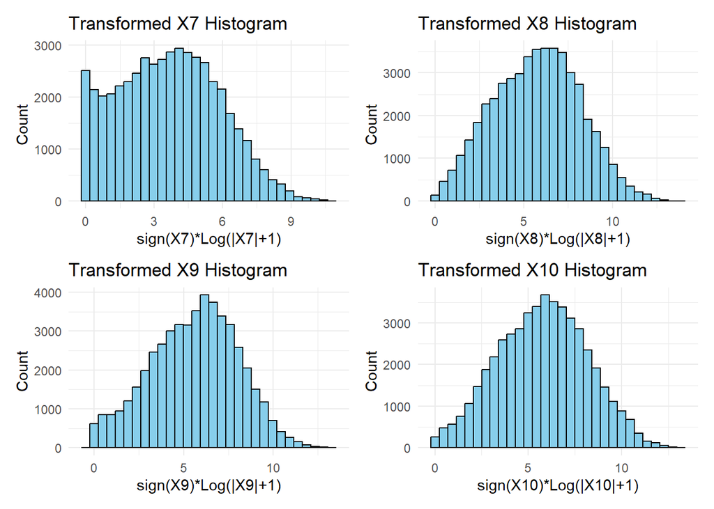

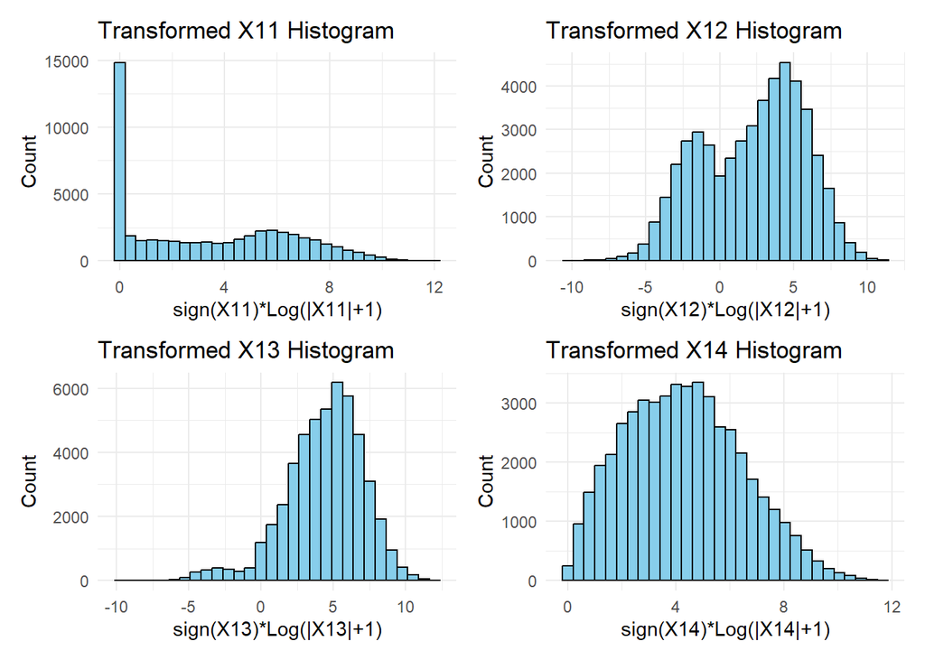

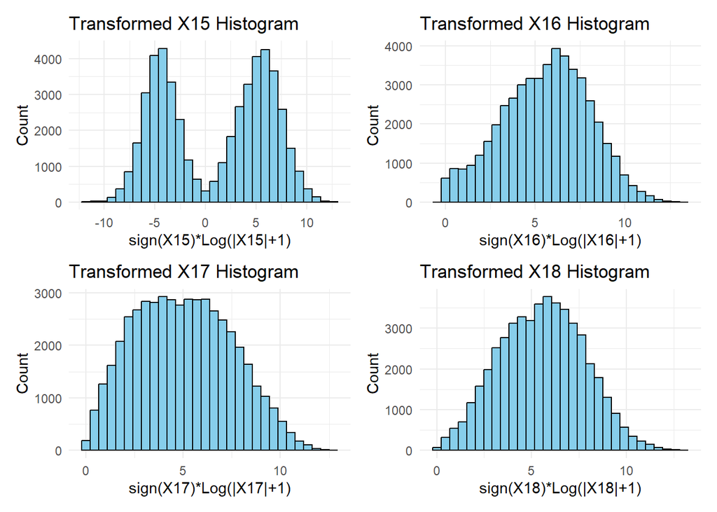

```r
histplots <- list()
for (var in covariates) {
  p <- ggplot(data = dataset, aes(x = log1p(abs(.data[[var]]))*sign(.data[[var]]))) +
     labs(title = paste("Transformed", var, "Histogram"), x = paste0("sign(",var,")*Log(|",var,"|+1)"), y = "Count") +
     geom_histogram(bins=30, color = "black", fill = "skyblue") +
     theme_minimal()

  histplots[[var]] <- p
}

histplot_groups <- split(histplots, ceiling(seq_along(histplots) / 4))

for (i in seq_along(histplot_groups)) {
  print(wrap_plots(histplot_groups[[i]], ncol = 2))
}
```

We see that many of the variables do not contain the symmetric and smooth structure associated with a normal distribution. Yet, all of the observations are taken into consideration and so we are not discarding any values. This transformation does reduce the impact that outliers have on our data, hence in the model analysis section of the report it is important that certain models use this transformed data.

We proceed onto measuring the correlation between variables.

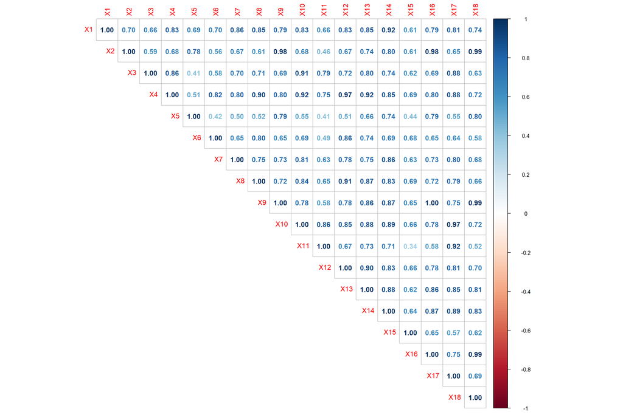

```r
cor_matrix <- cor(df_covariates)
corrplot(cor_matrix, method = "number", type="upper")
```

```r
identical(dataset$X9, dataset$X16)
```

```
## [1] TRUE
```

Therefore, we will remove variable X16 when we arrive to model analysis as it is completely identical to variable X9 so it will be of no use to us. We will now decide on whether a variable is deemed to be “highly correlated” to another variable. Since the incredibly high correlation figures, we choose any variable with a correlation value of greater than 0.95 to be deemed highly correlated.

```r
tmp <- cor(df_covariates)
tmp[upper.tri(tmp)] <- 0
diag(tmp) <- 0

to_remove <- apply(tmp, 2, function(x) any(abs(x) > 0.95))
correlated_vars <- data.frame(HighCorrelation = to_remove)
print(correlated_vars)
```

```
##     HighCorrelation
## X1            FALSE
## X2             TRUE
## X3            FALSE
## X4             TRUE
## X5            FALSE
## X6            FALSE
## X7            FALSE
## X8            FALSE
## X9             TRUE
## X10            TRUE
## X11           FALSE
## X12           FALSE
## X13           FALSE
## X14           FALSE
## X15           FALSE
## X16            TRUE
## X17           FALSE
## X18           FALSE
```

We see that the variables X2, X4, X9, X10 (and X16) are highly correlated to one or more variables within the dataset. Therefore, for possible further analysis in the model selection section part of the report, one may wish to remove them and see whether it improves their model.

This concludes the EDA section of the report. We have covered trends in the mean data over the years, showing that all variables follow a similar upwards trend. We have also identified the impact of outliers on our data and that many of the variables have high correlation. This will be of further use in the next part of the report.